# Exercse 3

# Task 1: Segmentation

Load fun packages.

```r
library(tidyverse)
library(ggpubr)
library(SimilarityMeasures)
theme_set(
  theme_classic()
)
```

Import caro data

```r
caro <- read_csv("0_rawdata/caro60.csv")
caro_original <- caro
```

## Specify a temporal window

Our sampling interval is 1 minute - if we take a temporal window of 6 minutes we use a window size of 6 positions. Therefore that’s 3 plus and 3 minus.

```r
caro %>%
  mutate(
    nMinus3 = sqrt((lag(E,3)-E)^2 + (lag(N,3)-N)^2),
    nMinus2 = sqrt((lag(E,2)-E)^2+(lag(N,2)-N)^2),
    nMinus1 = sqrt((lag(E,1)-E)^2+(lag(N,1)-N)^2),
    nPlus1  = sqrt((E-lead(E,1))^2+(N-lead(N,1))^2),
    nPlus2  = sqrt((E-lead(E,2))^2+(N-lead(N,2))^2),
    nPlus3  = sqrt((E-lead(E,3))^2+(N-lead(N,3))^2)
) -> caro

caro %>%
  rowwise() %>%
  mutate(
    stepMean = mean(c(nMinus3, nMinus2, nMinus1, nPlus1, nPlus2, nPlus3))
  ) %>%
  ungroup() -> caro
```

# Task 2: Specify and apply threshold *d*

Lets explore with a boxplot, histogram and summary.

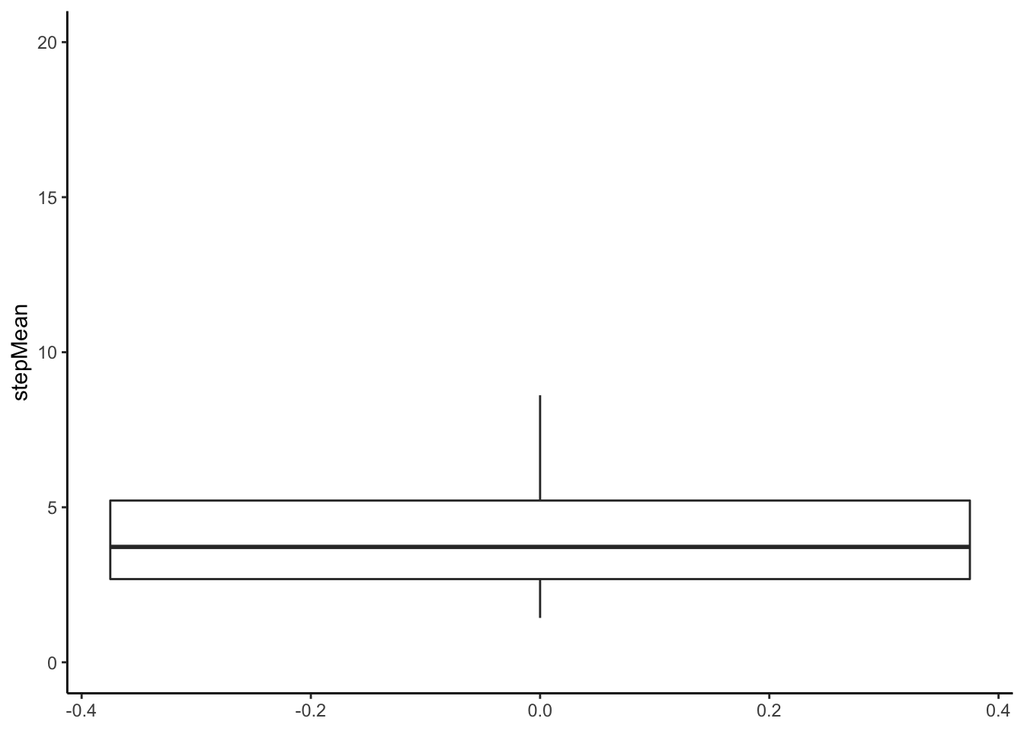

```r
ggplot(caro) +
  geom_boxplot(aes(y = stepMean), outlier.shape = NA)  +
  scale_y_continuous(limits = c(0, 20))
```

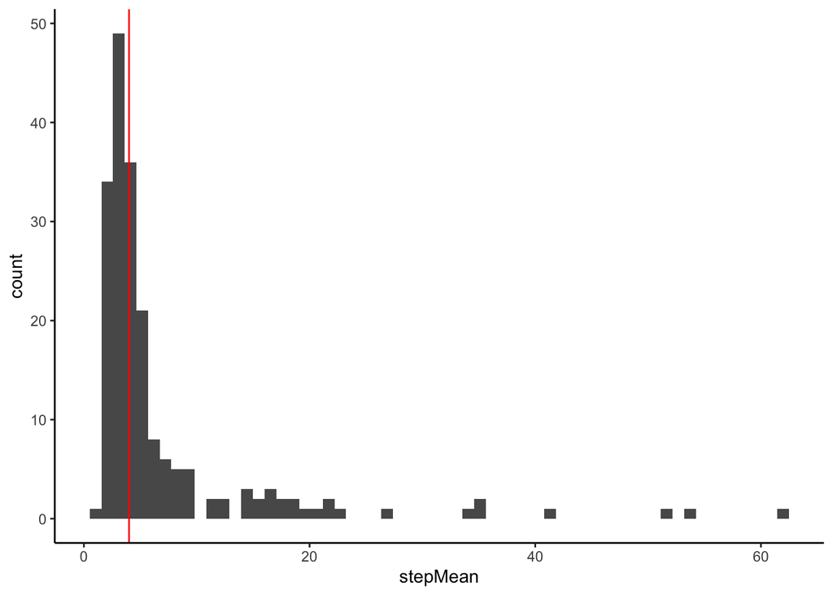

```r
ggplot(caro) +
  geom_histogram(aes(stepMean), bins = 60) + geom_vline(xintercept = 4, color = "red")
```

```r
summary(caro$stepMean)
```

```
##    Min. 1st Qu.  Median    Mean 3rd Qu.    Max.    NA's
##   1.431   2.729   3.962   6.951   6.164  62.368       6
```

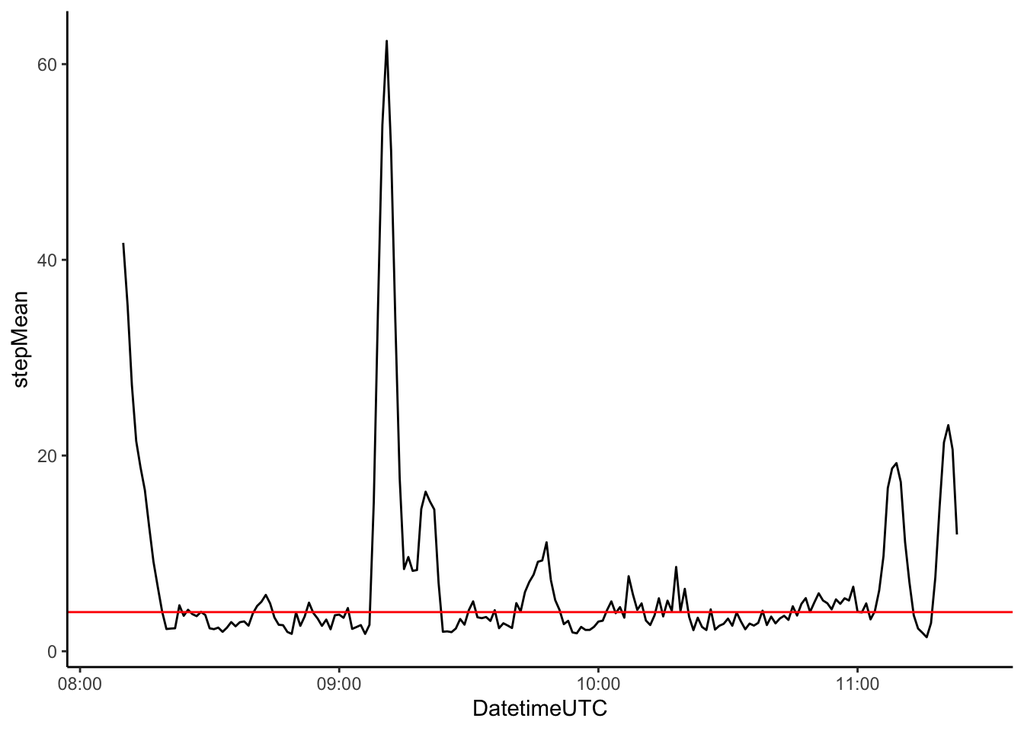

```r
ggplot(caro) +
  geom_line(aes(x=DatetimeUTC, y=stepMean)) +
  geom_hline(yintercept = 4, color = "red")
```

## Remove static points

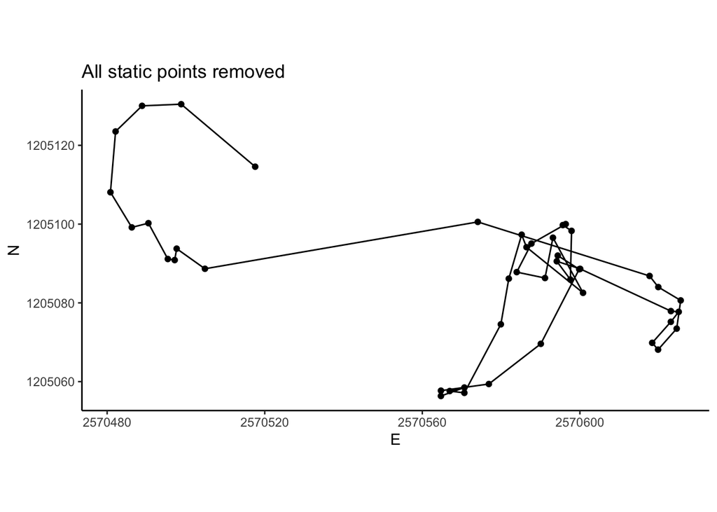

```r
caro %>%
  ungroup() %>%
  mutate(static = stepMean < mean(stepMean, na.rm = TRUE)) -> caro


caro %>%
  filter(!static) %>%
  ggplot(data = ., aes(x = E, y = N)) +
    geom_path() +
    geom_point() +
    coord_fixed() + labs(title = "All static points removed")
```

# Task 3 Visualise segmented trajectories

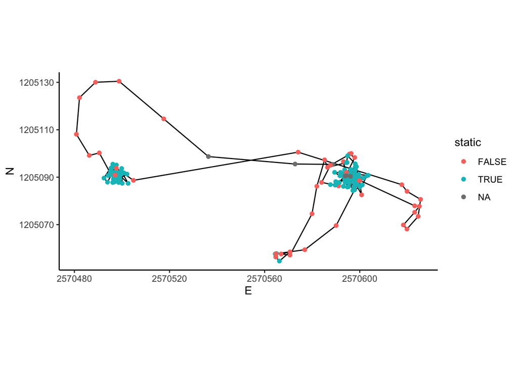

```r
ggplot(caro, aes(E, N)) +
  geom_path() +
  geom_point(aes(color = static)) +
  coord_equal()
```

# Task 4: Segment based analysis Functions to create unique IDs

```r
rle_id <- function(vec){
  x <- rle(vec)$lengths
  as.factor(rep(seq_along(x), times=x))
  }
```

Assign unique IDs to Caro and visualise all the segments.

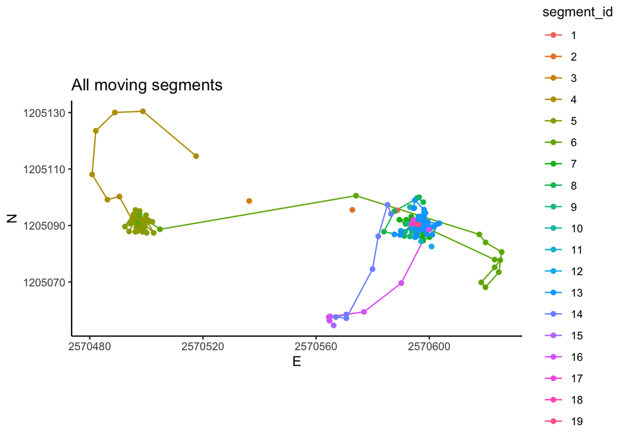

```r
caro %>%
  mutate(segment_id = rle_id(static)) -> caro

  ggplot(caro, aes(E, N, color = segment_id)) +
  geom_path() +
  geom_point() +
  coord_equal() + labs(title="All moving segments")
```

Now lets calculate the duration of each segment and remove the shorter segments (< 5 minutes)

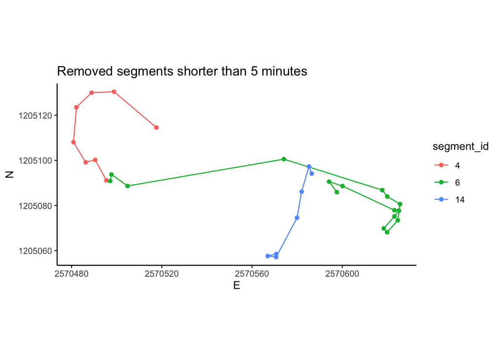

```r
caro %>%
  filter(!static) %>%
  group_by(segment_id) %>%
  mutate(duration = as.integer(difftime(max(DatetimeUTC),min(DatetimeUTC), units = "mins"))) %>%
  filter(duration > 5) %>%
  ggplot(., aes(E, N, color = segment_id)) +
  geom_path() +
  geom_point() +
  coord_equal() + labs(title="Removed segments shorter than 5 minutes")
```

# Task 5: Similarity measures

Import data

```r
pd <- read_csv("0_rawdata/pedestrian.csv")
```

Explore the trajectories

```r
pd
```

| TrajID | E | N | DatetimeUTC |
| --- | --- | --- | --- |
| 1 | 2571414 | 1205804 | 2015-03-01 12:01:00 |
| 1 | 2571396 | 1205791 | 2015-03-01 12:02:00 |
| 1 | 2571373 | 1205770 | 2015-03-01 12:03:00 |
| 1 | 2571347 | 1205753 | 2015-03-01 12:04:00 |
| 1 | 2571336 | 1205744 | 2015-03-01 12:05:00 |
| 1 | 2571321 | 1205732 | 2015-03-01 12:06:00 |
| 1 | 2571304 | 1205723 | 2015-03-01 12:07:00 |
| 1 | 2571285 | 1205706 | 2015-03-01 12:08:00 |
| 1 | 2571253 | 1205694 | 2015-03-01 12:09:00 |
| 1 | 2571219 | 1205674 | 2015-03-01 12:10:00 |

[output cut: 279 more lines]

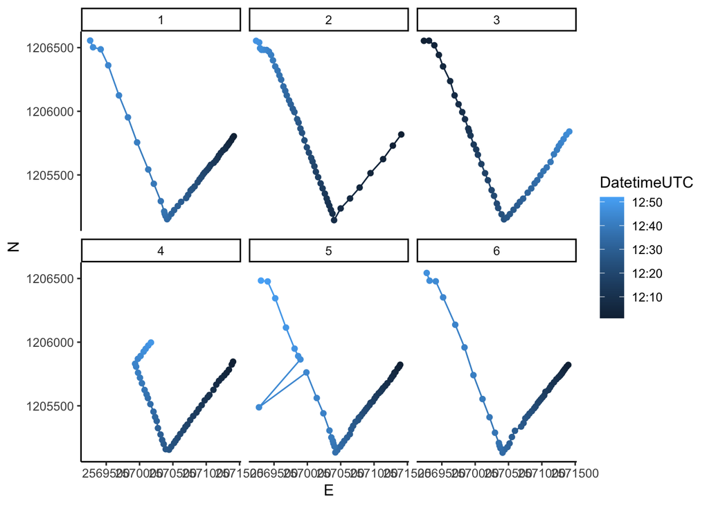

```r
ggplot(pd, aes(E, N, color = DatetimeUTC)) +
  geom_path() + geom_point() + facet_wrap(~TrajID)
```

```r
summary(pd)
```

```
##      TrajID            E                 N
##  Min.   :1.000   Min.   :2569231   Min.   :1205132
##  1st Qu.:2.000   1st Qu.:2570041   1st Qu.:1205364
##  Median :4.000   Median :2570515   Median :1205585
##  Mean   :3.526   Mean   :2570491   Mean   :1205643
##  3rd Qu.:5.000   3rd Qu.:2571009   3rd Qu.:1205807
##  Max.   :6.000   Max.   :2571414   Max.   :1206556
##   DatetimeUTC
##  Min.   :2015-03-01 12:01:00
##  1st Qu.:2015-03-01 12:13:00
##  Median :2015-03-01 12:25:00
##  Mean   :2015-03-01 12:24:37
##  3rd Qu.:2015-03-01 12:37:00
##  Max.   :2015-03-01 12:52:00
```

```r
pd %>%
  group_by(TrajID) %>%
  summarise(n = n())
```

| TrajID | n |
| --- | --- |
| 1 | 47 |
| 2 | 48 |
| 3 | 46 |
| 4 | 49 |
| 5 | 52 |
| 6 | 47 |

Trajectory 3 moved in reverse. Trajectory 4 has a differing shape and 5 has an outlier. Point density between the trajectories varies and highlights differences in speed.

# Task 6: Calculate similarity

First we need to get matrices!

An m x n matrix containing trajectory1. Here m is the number of points and n is the dimension of the points.

What does dimension mean?

```r
trajectories <- seq(2,5,1)
df <- NULL

for (i in trajectories) {
  pd %>% filter(TrajID == 1) %>% select(E, N) %>%  as.matrix() -> trj_1
  pd %>% filter(TrajID == i) %>% select(E, N) %>%  as.matrix() -> trj_2
  DTW(trj_1, trj_2) -> dtw_value
  EditDist(trj_1, trj_2) -> edit_dist_value
  Frechet(trj_1, trj_2) -> frechet_value
  LCSS(trj_1, trj_2, errorMarg = 15) -> lcss_value
  df <- rbind(df, data.frame(i, dtw_value, edit_dist_value, frechet_value, lcss_value))

}
```

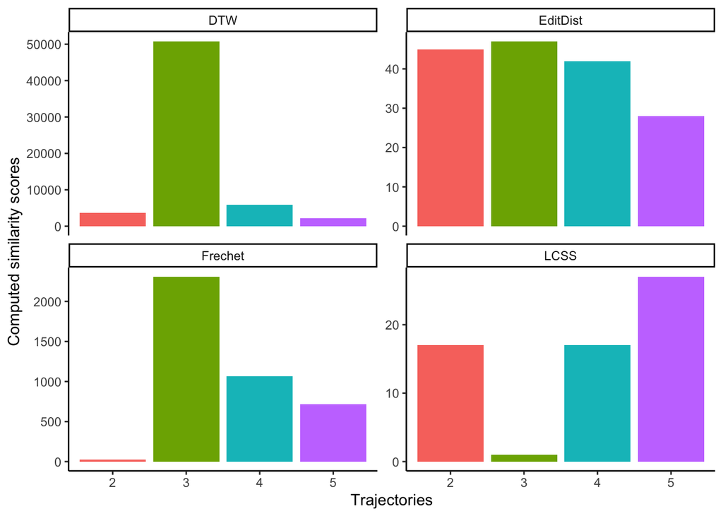

```r
df %>%
  rename(DTW = dtw_value, EditDist = edit_dist_value, Frechet = frechet_value, LCSS = lcss_value) %>%
  pivot_longer(2:5, names_to ="methods", values_to = "computed_similarities")%>%
  ggplot(., aes(x=as.factor(i), y=computed_similarities, fill = as.factor(i))) +
    geom_col() + facet_wrap(~methods, scales = "free_y") + theme(legend.position="none") +
  xlab("Trajectories") + ylab("Computed similarity scores")
```